# Analysis of Home Mortgage Disclosure Act Data

# Progression of Results

I wanted to begin with looking at the total loans originated between the two institutions and below are my results.

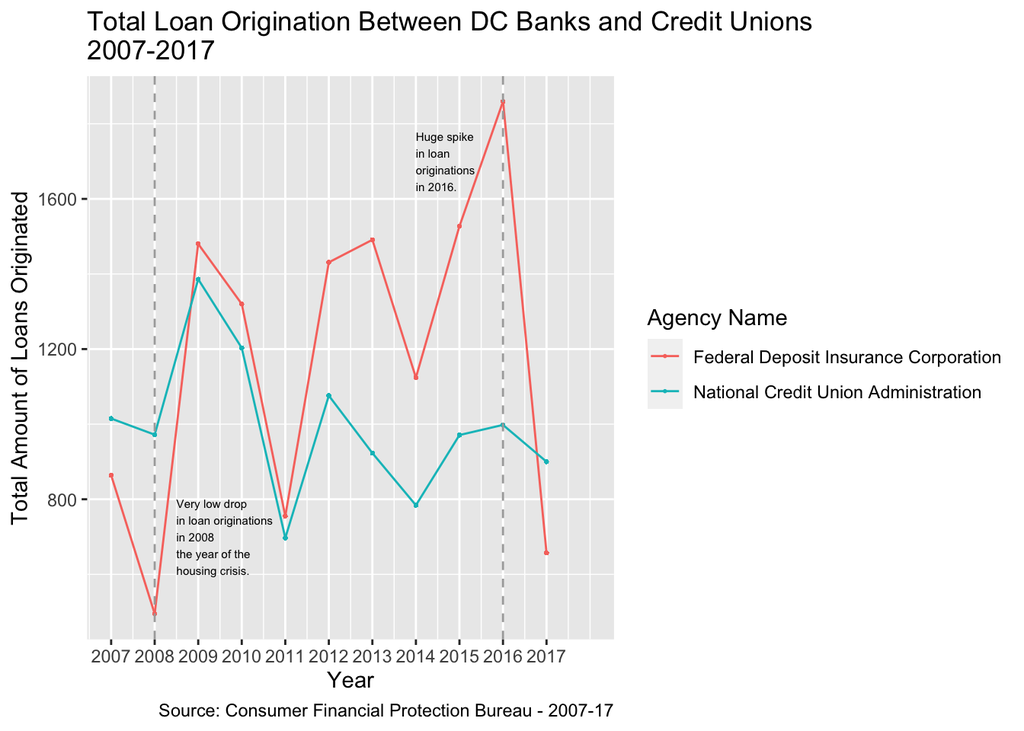

```r
totalLoansOverYears <- read_csv(here::here("data_processed", "totalLoansOverYears.csv"))
totalLoanOverYearsChart <- ggplot(totalLoansOverYears) +
    geom_line(aes(x = year, y = n,  group = agency_code, color = agency_name))+
    geom_point(aes(x = year, y = n,  group = agency_code, color = agency_name), size = 0.3)+
    labs(
        title = 'Total Loan Origination Between DC Banks and Credit Unions\n2007-2017',
        x = 'Year',
        y = 'Total Amount of Loans Originated',
        caption = "Source: Consumer Financial Protection Bureau - 2007-17",
        color = 'Agency Name'
    )+
    scale_x_continuous(limits=c(2007, 2018), breaks=c(2007, 2008, 2009, 2010, 2011, 2012, 2013, 2014, 2015, 2016, 2017))+
    geom_vline(xintercept = 2008, col = 'darkgrey',
               linetype = 'dashed')+
    geom_vline(xintercept = 2016, col = 'darkgrey',
               linetype = 'dashed')+
    annotate('text', x = 2008.5, y = 700,
             label = 'Very low drop \nin loan originations \nin 2008 \nthe year of the\nhousing crisis.',
             color = 'black', size = 2, hjust = 0)+
    annotate('text', x = 2014, y = 1700,
             label = 'Huge spike \nin loan\noriginations \nin 2016.',
             color = 'black', size = 2, hjust = 0)
ggsave(filename = file.path('images', 'totalLoanOverYearsChart.png'),
       plot   = totalLoanOverYearsChart,
       width  = 10,
       height = 6)
totalLoanOverYearsChart
```

As you can see, the first visualization definitely did not prove that credit unions provided better mortgage opportunities for their members. I realized in general, banks may have more members than credit unions and therefore I should create a variable to normalize the data. You will see below that I measured the percent of loans originated over the total applicant pool for each institution over the years. To my dismay, it did not show much of a difference from the first graph.

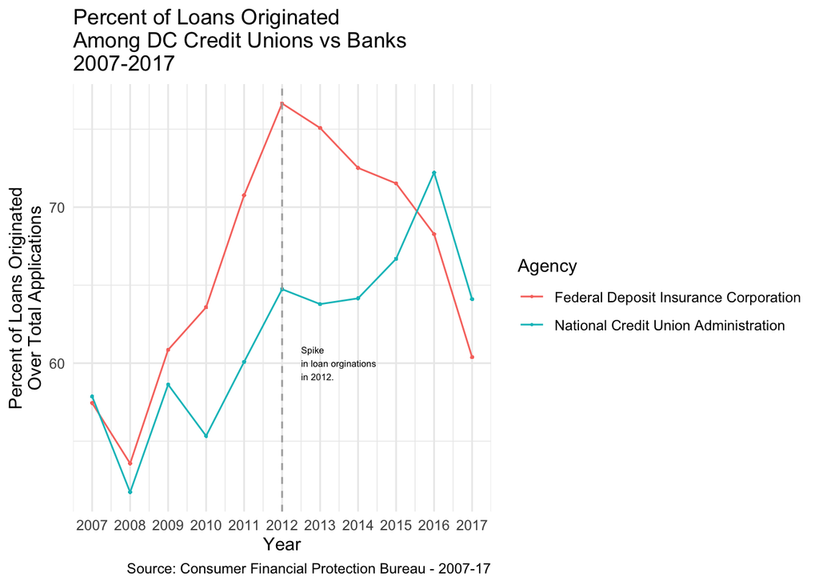

```r
ratesBoth <- read_csv(here::here("data_processed", "ratesBoth.csv"))
totalRateOverYearsChart <- ggplot(ratesBoth, aes(x = year, y = rate)) +
    geom_line(aes(group = agency_code, color = agency_name))+
    geom_point(aes(group = agency_code, color = agency_name), size = 0.3)+
    theme_minimal()+
    labs(
        title = 'Percent of Loans Originated\nAmong DC Credit Unions vs Banks\n2007-2017',
        x = 'Year',
        y = 'Percent of Loans Originated\nOver Total Applications',
        caption = "Source: Consumer Financial Protection Bureau - 2007-17",
        color = "Agency"
    )+
    geom_vline(xintercept = 2012, col = 'darkgrey',
               linetype = 'dashed')+
    annotate('text', x = 2012.5, y = 60,
             label = 'Spike \nin loan orginations \nin 2012.',
             color = 'black', size = 2, hjust = 0)+
    scale_x_continuous(limits=c(2007, 2017), breaks=c(2007, 2008, 2009, 2010, 2011, 2012, 2013, 2014, 2015, 2016, 2017))
totalRateOverYearsChart
```

Even when the two institutions are put on even playing fields, the data shows that banks tend to provide more mortgage loan originations than credit unions. As explained before, according to the Federal Reserve, mortgage interest rates hit record lows in 2012 which explains for the increase in loan originations that year.

Therefore, I found I should possibly look at a different metric to compare the data and hopefully attribute to the answer I expected. I created graphs looking at the applicant income of loans originated between the two institutions.

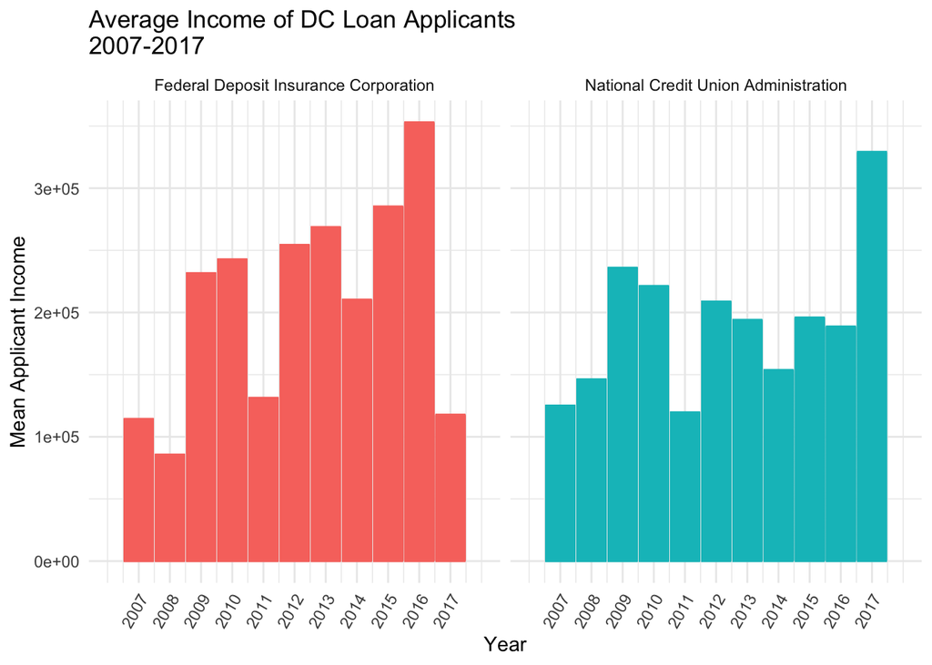

```r
averageIncomeAcceptance <- ggplot(totalLoansOverYears) +
    geom_col(aes(x = year, y = meanApplicantIncome, color = agency_name))+
    facet_wrap(~agency_name)+
    labs(x = "Year", y = "Mean Applicant Income", title = "Average Income of DC Loan Applicants\n2007-2017",
         colour = NULL)+
    theme_minimal()+
    theme(legend.position = 'none')+
    theme(axis.text.x = element_text(angle = 60, hjust = 1))+
    scale_x_continuous(limits=c(2006, 2018), breaks=c(2007, 2008, 2009, 2010, 2011, 2012, 2013, 2014, 2015, 2016, 2017))
averageIncomeAcceptance
```

```r
ggsave(filename = file.path('data_processed', 'averageIncomeAcceptance.pdf'),
       plot   = averageIncomeAcceptance,
       width  = 10,
       height = 6)
ggsave(filename = file.path('images', 'averageIncomeAcceptance.png'),
       plot   = averageIncomeAcceptance,
       width  = 10,
       height = 6)
```

The two entities compared in this chart are the two agencies of institutions and the variables highlighted in this chart are average applicant income over year. By faceting the charts, you can see that overall the average applicant income whose loans were originated are much lower for credit unions over the years 2010-2016. However, there is a huge difference in the years 2017 and 2008 where banks tend to originate loans for applicants with lower income.

The average income fluctuated quite frequently so I found it useful to continue on to graph the median income among applicants whose loans were originated over the years. I also improved on my visualizations by using dodged bars in this next visualization.

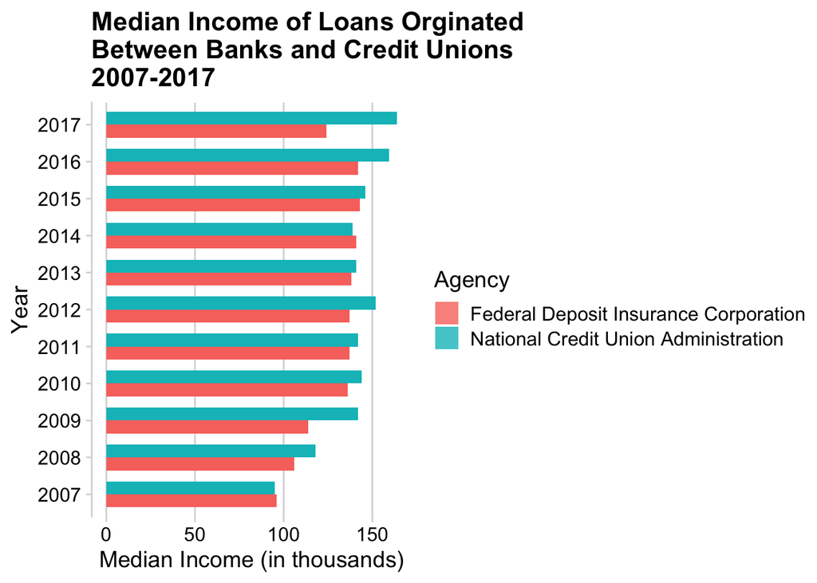

```r
loansOrig7_17 <- read_csv(here::here("data_processed", "loansOrig7_17.csv"))
ggplot(loansOrig7_17) +
    geom_col(aes(x = as.factor(year),
                 y = median_income, fill = agency_name),
             position = 'dodge',
             width = 0.7, alpha = 0.8)+
    coord_flip() +
    theme_minimal_vgrid() +
    labs(x = 'Year',
         y = 'Median Income (in thousands)',
         fill = 'Agency',
         title = 'Median Income of Loans Orginated\nBetween Banks and Credit Unions\n2007-2017')
```

## Conclusions and Possible Future Exploration

As seen with my data, nothing supports my original expectations of credit unions significantly providing better mortgage opportunities than banks. In this case, the answer to my research question is a clear no. I am shocked to say the least, but as they say “the facts don’t lie.”

In the future I can definitely explore different variables the raw data includes. In my report I focus on purely numbers but it might be interesting to look at the differences among loan applicants with varying ethnicity and race. Another variable to look at could be applicant sex, I could facet graphs to see the relationship between loans originated and those variables.

In conclusion, the data shown completely shocked my expectation and as of right now points to the answer: no, credit unions don’t seem as beneficial as banks in providing mortgage opportunities. # Appendix

### Data Dictionary For Raw Data

For further detail on each variable here is a URL with the source: https://files.consumerfinance.gov/hmda-historic-data-dictionaries/lar_record_codes.pdf

| Variable Name | Variable Type | Variable Description |
| --- | --- | --- |
| As of Year | Numeric | The year data was reported |
| Respondent ID | Alphanumeric | 10 Character Identifier for each institution |
| Agency Code | Alphanumeric | Each agency the institution falls under is assigned a number: 1 = Office of the Comptroller of the Currency (OCC), Federal Reserve System (FRS), 3 = Federal Deposit Insurance Corporation (FDIC), 5 = N… |
| Loan Type | Numeric | Each type is assigned a number:1 = Conventional (any loan other than FHA, VA, FSA, or RHS loans), 2 = FHA-insured (Federal Housing Administration), 3 = VA-guaranteed (Veterans Administration), 4 = FSA… |
| Property Type | Alphanumeric | Each property type is assigned a number |
| Loan Purpose | Numeric | Each loan purpose is assigned a number : 1 = House purchase, 2 = Home improvement, 3 = Refinancing |
| Occupancy | Numeric | Each owner occupancy is assigned a number: 1 = Owner occupied as a principal dwelling, 2 = not owner occupied, 3 = not applicable |
| Loan Amount (000s) | Numeric | In thousands of dollars |
| Preapproval | Alphanumeric | 1 = preapproval was request, 2 = preapproval was not requested, 3 = not applicable |
| Action Type | Numeric | Action taken once the loan was applied for. 1 = loan originated, 2 = Application approved but not accepted, 3 = Application denied by financial institution, 4 = Application withdrawn by applicant, 5 =… |
| MSA/MD | Alphanumeric | Metropolitan Statistical Area/Metropolitan Division |
| State Code | Alphanumeric | Two-digit FIPS state identifier |
| County Code | Alphanumeric | Three-digit FIPS county identifier |
| Tract | Alphanumeric | Census tract number |
| Applicant Ethnicity | Alphanumeric | Each ethnicity is assigned a number: 1 = Hispanic or Latino, 2 = Not Hispanic or Latino, 3 = - Information not provided by applicant in mail, Internet, or telephone application, 4 = Not applicable, 5 … |
| Co Applicant Ethnicity | Alphanumeric | Each co applicant ethnicity is assigned a number |
| Applicant Race 1 | Alphanumeric | Each race is assigned a variable number: 1 = American Indian or Alaska Native |
| Applicant Race 2 | Alphanumeric | Asian |
| Applicant Race 3 | Alphanumeric | Black or African American |
| Applicant Race 4 | Alphanumeric | Native Hawaiian or Other Pacific Islander |
| Applicant Race 5 | Alphanumeric | White |
| Co Applicant Race 1 | Alphanumeric | Each co applicant race is assigned a variable number: 1 = American Indian or Alaska Native |
| Co Applicant Race 2 | Alphanumeric | Asian |
| Co Applicant Race 3 | Alphanumeric | Black or African American |
| Co Applicant Race 4 | Alphanumeric | Native Hawaiian or Other Pacific Islander |
| Co Applicant Race 5 | Alphanumeric | White |
| Applicant Sex | Numeric | Each applicant sex is assigned a number: 1 = male, 2 = female, 3 = information not provided, 4 = not applicable, 5 = no co-applicant |
| Co Applicant Sex | Numeric | Each co applicant sex is assigned a number: |
| Applicant Income (000s) | Alphanumeric | In thousands of dollars |
| Purchaser Type | Alphanumeric | Each type of purchaser is assigned a number (ex: 1 = Fannie Mae) |
| Denial Reason 1 | Alphanumeric | Each loan denial is assigned a number / its own variable: 1 = Debt-to-income ratio |
| Denial Reason 2 | Alphanumeric | Employment history |
| Denial Reason 3 | Alphanumeric | Credit history |
| HOEPA Status | Alphanumeric | 1 = HOEPA loan, 2 = Not a HOEPA loan |
| Lien Status | Alphanumeric | (only for applications and origination) Each status is assigned a number (ex: 1 = Secured by a first lien) |
| Edit Status | Alphanumeric | Each edit is assigned a number (ex: 5 = validity edit failure only) |
| Sequence Number | Alphanumeric | One-up number scheme for each respondent |
| Population | Alphanumeric | Total population in tract |
| Minority Population % | Alphanumeric | Percentage of minority population to total population for tract |
| FFIEC Median Family Income | Alphanumeric | In dollars |
| Tract to MSA/MD Income % | Alphanumeric | Percentage of tract median family income compared to MSA/MD median family income |
| Number of Owner-occupied units | Alphanumeric | Number of dwellings that are lived in by the owner |
| Number of 1-to 4-Family units | Alphanumeric | Number of dwellings built to house fewer than 5 families |
| Application Date Indicator | Numeric | Whether or not the application was filled before or after 01-01-2004 |

### Data Dictionary for totalLoansOverYears data set

This is to show an example of one of the datasets I used and how I drastically gutted the raw data so I could utilize the relevant variables for my report.

| Variable Name | Variable Type | Variable Description |
| --- | --- | --- |
| year | double | years 2007-2017 |
| n | double | total number of loans originated for each institution per year |
| agency_code | agency code, either 3 or 5 |  |
| agency_name | character | FDIC or NCUA |
| applicant_income_000s | double | in thousands of dollars |
| meanApplicantIncome | double | in thousands of dollars |

# Works Cited

Bhutta, Neil, et al. “Residential Mortgage Lending in 2016: Evidence from the Home Mortgage Disclosure Act Data - November 2017.” Board of Governors of the Federal Reserve System, Nov. 2017, www.federalreserve.gov/publications/2017-november-residential-mortgage-lending-in-2016.htm.

Credit Unions Vs. Banks — US Community Credit Union. US Community Credit Union, www.usccu.org/news/credit-unions-vs-banks.

“Home Mortgage Disclosure Act.” Home Mortgage Disclosure Act, FFEIC, www.ffiec.gov/hmda/.

Oyedele, Akin. 2016 was the best year for the US housing market since the financial crisis. Business Insider, Insider, 26 Jan. 2017, www.businessinsider.com/new-home-sales-december-2017-2017-1. Accessed 4 May 2020.